# Assignment 4

Cheng Zhang cz2532

October 24, 2018

```r
setwd("C:/Users/Alan_/Desktop/Semester1 Courses/STAT computing/week 6/assignment4")
debt <- read.csv("debt.csv", as.is = TRUE)
dim(debt)
```

```
## [1] 1171    4
```

```r
head(debt)
```

```
##     Country Year    growth     ratio
## 1 Australia 1946 -3.557951 190.41908
## 2 Australia 1947  2.459475 177.32137
## 3 Australia 1948  6.437534 148.92981
## 4 Australia 1949  6.611994 125.82870
## 5 Australia 1950  6.920201 109.80940
## 6 Australia 1951  4.272612  87.09448
```

1. Calculate the average GDP growth rate for each country (averaging over years). This is a classic split/apply/combine problem, and you will use daply() to solve it.
1. Begin by writing a function, mean.growth(), that takes a data frame as its argument and returns the mean of the `growth` column of that data frame.
2. Use daply() to apply mean.growth() to each country in debt. Don’t use some- thing like mean(debt$growth[debt$Country==“Australia”]), except to check your work. You should not need to use a loop to do this. (The average growth rates for Australia and the Netherlands should be 3:72 and 3:03. Print these values.) Report the average GDP growth rates clearly.

```r
mean.growth <- function(df = debt, column = "growth"){
  mean_g = mean(df[,column])
  return(mean_g)
}

library(plyr)
country_avg <- daply(debt, .(Country), mean.growth)
signif(country_avg["Australia"],3)
```

```
## Australia
##      3.72
```

```r
signif(country_avg["Netherlands"],3)
```

```
## Netherlands
##        3.03
```

2. Using the same instructions as problem 1, calculate the average GDP growth rate for each year (now averaging over countries). (The average growth rates for 1972 and 1989 should be 5:63 and 3:19, respectively. Print these values in your output.) Make a plot of the growth rates (y-axis) versus the year (x-axis). Make sure the axes are labeled appropriately.

```r
year_avg <- daply(debt, .(Year), mean.growth)
signif(year_avg["1972"],3)
```

```
## 1972
## 5.63
```

```r
signif(year_avg["1989"],3)
```

```
## 1989
## 3.19
```

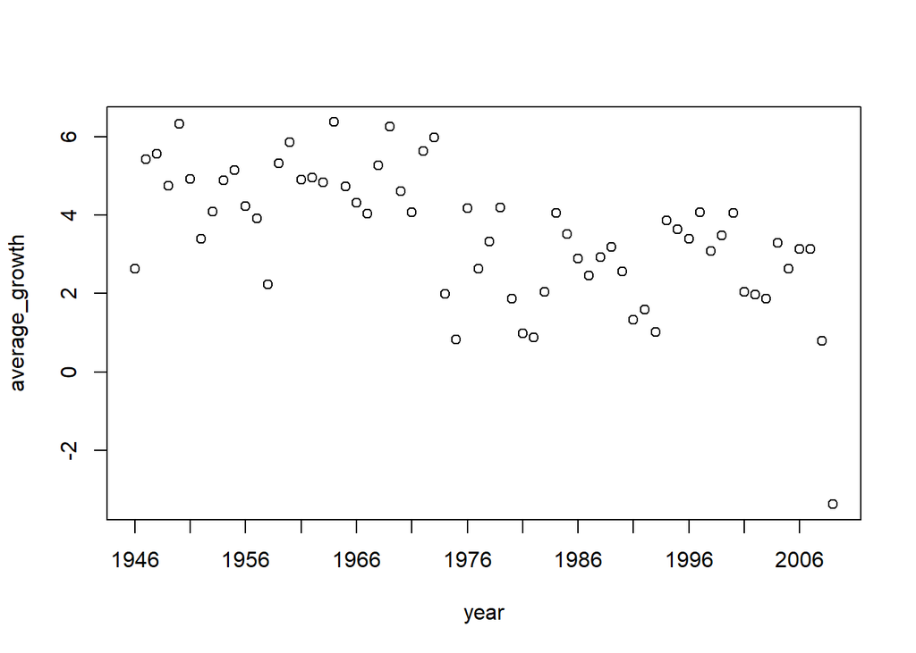

```r
plot(year_avg, xlab = "year", ylab = "average_growth", xaxt="n")
axis(1,at = seq(1, 64, by=5 ),labels = seq(1946, 2009, by=5 ))
```

3. The function cor(x,y) calculates the correlation coeficient between two vectors x and y.
1. Calculate the correlation coeficient between GDP growth and the debt ratio over the whole data set (all countries, all years). Your answer should be 0:1995.
2. Compute the correlation coeficient separately for each country, and plot a his- togram of these coeficients (with 10 breaks). The mean of these correlations should be 0:1778. Do not use a loop. (Hint: consider writing a function and then making it an argument to daply()).
3. Calculate the correlation coeficient separately for each year, and plot a histogram of these coeficients. The mean of these correlations should be 0:1906.
4. Are there any countries or years where the correlation goes against the general trend?

```r
signif(cor(debt[,"growth"], debt[,"ratio"]),4)
```

```
## [1] -0.1995
```

##### The output is the same with the given number.

```r
cor_growth_ratio <- function(df = debt, column1 = "growth", column2 = "ratio"){
  correlation = cor(df[,column1], df[,column2])
  return(correlation)
}

country_cor <- daply(debt, .(Country), cor_growth_ratio)
signif(mean(country_cor),4)
```

```
## [1] -0.1778
```

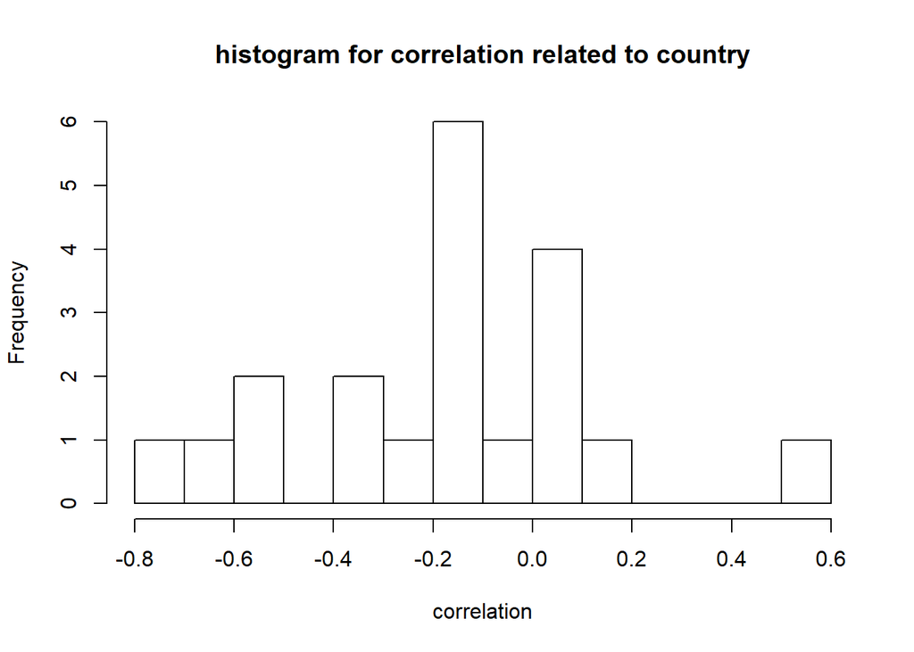

```r
hist(country_cor, breaks = 10, main = "histogram for correlation related to country", xlab = "correlation")
```

##### This output is the same with the given number.

```r
year_cor <- daply(debt, .(Year), cor_growth_ratio)
signif(mean(country_cor),4)
```

```
## [1] -0.1778
```

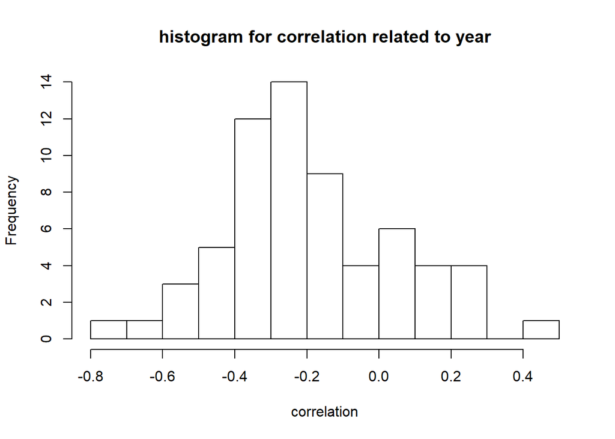

```r
hist(year_cor, breaks = 10, main = "histogram for correlation related to year", xlab = "correlation")
```

```r
signif(country_cor[country_cor>0.3],3)
```

```
## Norway
##  0.563
```

```r
signif(year_cor[year_cor>0.3],3)
```

```
##  1978
## 0.431
```

##### According to previous two plot, there are one country and one year whose correlation goes against general trend. The country is Norway with correlation of 0.563. The year is 1978 with correlation 0.431.

4. Fit a linear model of overall growth on the debt ratio, using lm(). Report the intercept and slope. Make a scatter-plot of overall GDP growth (vertical) against the overall debt ratio (horizontal). Add a line to your scatterplot showing the tted regression line.

```r
lm_overall <- lm(debt[,"growth"]~debt[,"ratio"])
signif(lm_overall$coefficients[1],3)
```

```
## (Intercept)
##        4.28
```

```r
signif(lm_overall$coefficients[2],3)
```

```
## debt[, "ratio"]
##         -0.0184
```

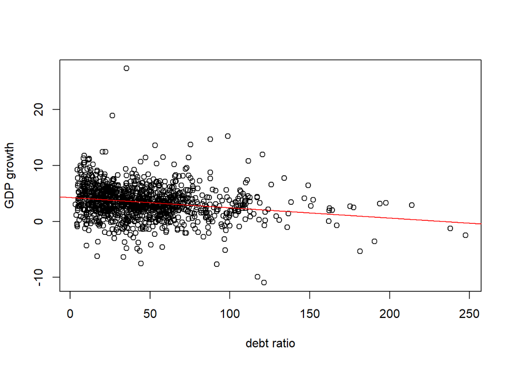

```r
plot(debt[,"ratio"],debt[,"growth"],xlab = "debt ratio",ylab = "GDP growth")
abline(lm_overall,col="red")
```

##### The intercept is 4.28. The slope is -0.0184

5. There should be four countries with a correlation smaller than -0.5. Separately, plot GDP growth versus debt ratio from each of these four countries and put the coun- try names in the titles. This should be four plots. Call par(mfrow=c(2,2)) before plotting so all four plots will appear in the same figure. (Think about what this shows: individual relationships at the country level are some- times concealed or “smudged out” when data is aggregated over all groups (countries). This conveys the importance of careful analysis at a more granular group level, when such groupings are available!)

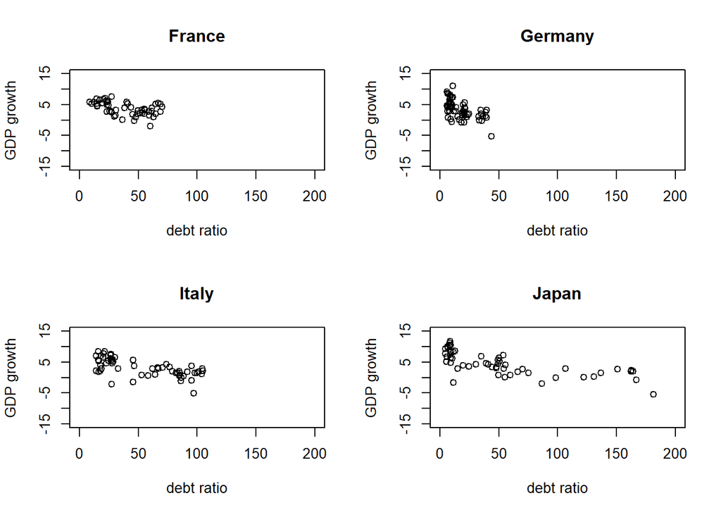

```r
country_name <- rownames(data.frame(country_cor[country_cor < -0.50]))
par(mfrow=c(2,2))
plot(debt[debt["Country"] == country_name[1],"ratio"], debt[debt["Country"] == country_name[1],"growth"], xlab = "debt ratio", ylab = "GDP growth", xlim = c(0,200), ylim = c(-15,15), main = country_name[1])
plot(debt[debt["Country"] == country_name[2],"ratio"], debt[debt["Country"] == country_name[2],"growth"], xlab = "debt ratio", ylab = "GDP growth", xlim = c(0,200), ylim = c(-15,15), main = country_name[2])
plot(debt[debt["Country"] == country_name[3],"ratio"], debt[debt["Country"] == country_name[3],"growth"], xlab = "debt ratio", ylab = "GDP growth", xlim = c(0,200), ylim = c(-15,15), main = country_name[3])
plot(debt[debt["Country"] == country_name[4],"ratio"], debt[debt["Country"] == country_name[4],"growth"], xlab = "debt ratio", ylab = "GDP growth", xlim = c(0,200), ylim = c(-15,15), main = country_name[4])
```

6. Some economists claim that high levels of government debt cause slower growth. Other economists claim that low economic growth leads to higher levels of government debt. The data file, as given, lets us relate this year’s debt to this year’s growth rate; to check these claims, we need to relate current debt to future growth.
1. Create a new data frame which just contains the rows of debt for France, but contains all those rows. It should have 54 rows and 4 columns (print the dimen- sions of your data frame). Note that some years are missing from the middle of this data set.
2. Create a new column in your data frame for France, next.growth, which gives next year’s growth if the next year is in the data frame, or NA if the next year is missing. (next.growth for 1971 should be (rounded) 5:886, but for 1972 it should be NA. Print these two values.)

```r
debt_france <- debt[debt[,"Country"] == "France",]
dim(debt_france)
```

```
## [1] 54  4
```

##### There are 54 rows and 4 colums in the new dataframe, which is the same with the given number.

```r
for (i in (1:53)){
  ifelse(debt_france[i,"Year"]+1 == debt_france[i+1,"Year"], debt_france[i,"next.growth"] <- debt_france[i+1,"growth"], debt_france[i,"next.growth"] <- NA)
}

signif(debt_france[debt_france[,"Year"]==1971,"next.growth"],4)
```

```
## [1] 5.886
```

```r
signif(debt_france[debt_france[,"Year"]==1972,"next.growth"],4)
```

```
## [1] NA
```

##### The next.growth for 1971 is 5.886. The next.growth for 1972 is NA. All of them are same with the given value.

7. Add a next.growth column, as in the previous question, to the whole of the debt data frame. Make sure that you do not accidentally put the first growth value for one country as the next.growth value for another. (The next.growth for France in 2009 should be NA, not 9.167. Print this value.) Hints: Write a function to encapsulate what you did in the previous question, and apply it using ddply().

```r
debt_country <- function(df){
  n <- dim(df)[1]-1
  for (i in 1:n){
    ifelse(df[i,"Year"]+1 == df[i+1,"Year"], df[i,"next.growth"] <- df[i+1,"growth"], df[i,"next.growth"] <- NA)
  }
  return(df)
}

debt <- ddply(debt, .(Country), debt_country)

debt[debt[,"Country"]=="France" & debt[,"Year"]=="2009", "next.growth"]
```

```
## [1] NA
```

##### The next.growth for France in 2009 is NA, which is the same as the given value.

8. Make a scatter-plot of next year’s GDP growth against this year’s debt ratio. Linearly regress next year’s growth rate on the current year’s debt ratio, and add the line to the plot. Report the intercept and slope to reasonable precision. How do they compare to the regression of the current year’s growth on the current year’s debt ratio?

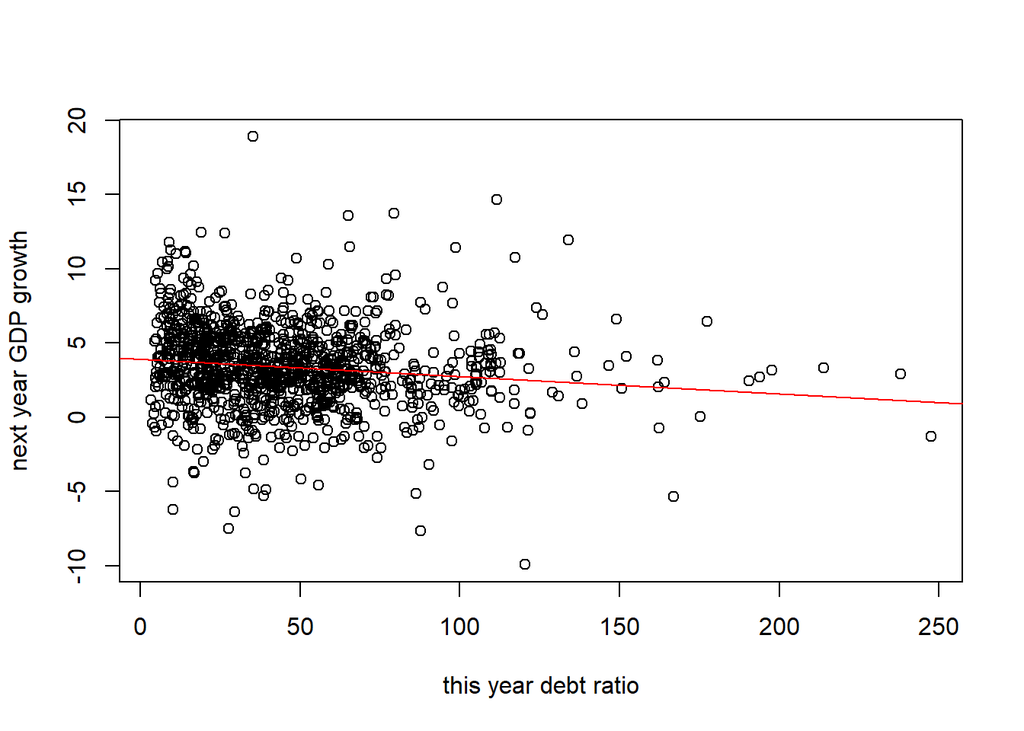

```r
x <- debt[,"ratio"]
y <- debt[,"next.growth"]
plot(x, y, ylab = "next year GDP growth", xlab = "this year debt ratio")
lm_new <- lm(y~x)
abline(lm_new, col = "red")
```

```r
signif(lm_new$coefficients[1],3)
```

```
## (Intercept)
##        3.92
```

```r
signif(lm_new$coefficients[2],3)
```

```
##       x
## -0.0116
```

##### The intercept is 3.92 and the slope is -0.0116

##### Comparing to the regression of the current year’s growth on the current year’s debt ratio, this regrssion line has smaller inercept and bigger slope. Since the slope is negative, this line is less sharp. Hpwever, the general trend of these two lines is very similar.

9. Make a scatter-plot of next year’s GDP growth against the current year’s GDP growth. Linearly regress next year’s growth on this year’s growth, and add the line to the plot. Report the coeficients. Can you tell, from comparing these two simple regressions (from the current question, and the previous), whether current growth or current debt is a better predictor of future growth?

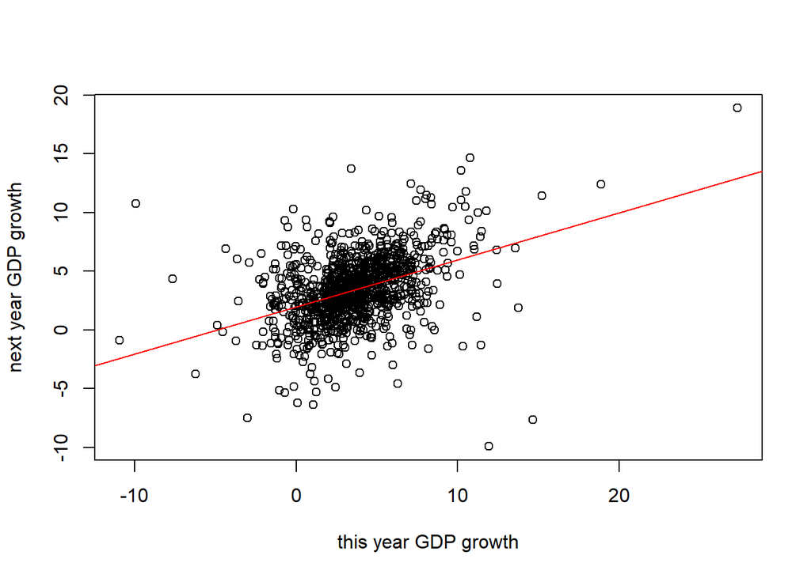

```r
x <- debt[,"growth"]
y <- debt[,"next.growth"]
plot(x, y, ylab = "next year GDP growth", xlab = "this year GDP growth")
lm_new2 <- lm(y~x)
abline(lm_new2, col = "red")
```

```r
signif(lm_new2$coefficients[1],3)
```

```
## (Intercept)
##        1.97
```

```r
signif(lm_new2$coefficients[2],3)
```

```
##     x
## 0.401
```

##### The intercept is 1.97 and the slope is 0.401.

##### The current growth is the better predictor of next year GDP growth. Since its slope is bigger, it can better tell the difference of y when x changes.